# Declining Movie Attendance

Max Wagner

December 4, 2015

# Introduction

# Movie Admissions

Taking a table from NATO Online, we can see the total admissions by year in the US and Canada combined. The `Admissions` column is in billions. There is a clear trend of increasing attendance from 1987 to the early 2000’s, and a definite decline from then until present day. White Hutchinson Leisure and Learning Group reported a 27% drop in revenue since 2002 to acompany the decline in admissions. There are number of possible reasons for the trend of rise and decline. We’ll take a look at a few of the possible factors in the next section.

| Year | Admissions | Year | Admissions |
| --- | --- | --- | --- |
| 1987 | 1.090 | 2001 | 1.438 |
| 1988 | 1.080 | 2002 | 1.570 |
| 1989 | 1.260 | 2003 | 1.521 |
| 1990 | 1.190 | 2004 | 1.484 |
| 1991 | 1.140 | 2005 | 1.376 |
| 1992 | 1.099 | 2006 | 1.401 |
| 1993 | 1.182 | 2007 | 1.400 |
| 1994 | 1.240 | 2008 | 1.341 |
| 1995 | 1.211 | 2009 | 1.414 |
| 1996 | 1.319 | 2010 | 1.339 |
| 1997 | 1.354 | 2011 | 1.280 |
| 1998 | 1.438 | 2012 | 1.360 |
| 1999 | 1.440 | 2013 | 1.340 |
| 2000 | 1.383 | 2014 | 1.270 |

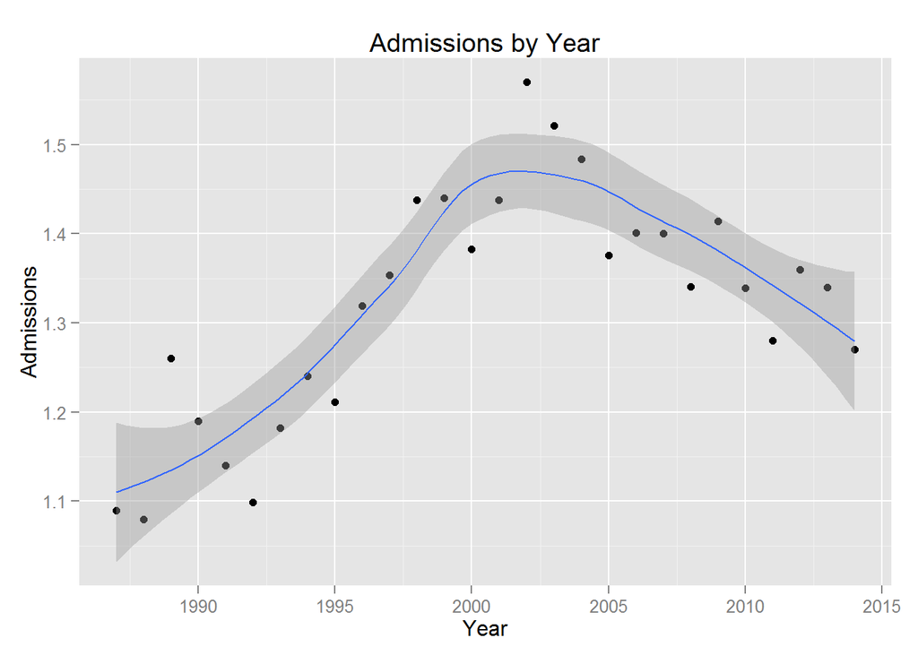

# Ticket Prices

|  | Year | Price | Year | Price |
| --- | --- | --- | --- | --- |
| 20 | 1987 | 3.91 | 2001 | 5.65 |
| 21 | 1988 | 4.11 | 2002 | 5.80 |
| 22 | 1989 | 3.99 | 2003 | 6.03 |
| 23 | 1990 | 4.22 | 2004 | 6.21 |
| 24 | 1991 | 4.21 | 2005 | 6.41 |
| 25 | 1992 | 4.15 | 2006 | 6.55 |
| 26 | 1993 | 4.14 | 2007 | 6.88 |
| 27 | 1994 | 4.08 | 2008 | 7.18 |
| 28 | 1995 | 4.35 | 2009 | 7.50 |
| 29 | 1996 | 4.42 | 2010 | 7.89 |
| 30 | 1997 | 4.59 | 2011 | 7.93 |
| 31 | 1998 | 4.69 | 2012 | 7.96 |
| 32 | 1999 | 5.06 | 2013 | 8.13 |
| 33 | 2000 | 5.39 | 2014 | 8.17 |

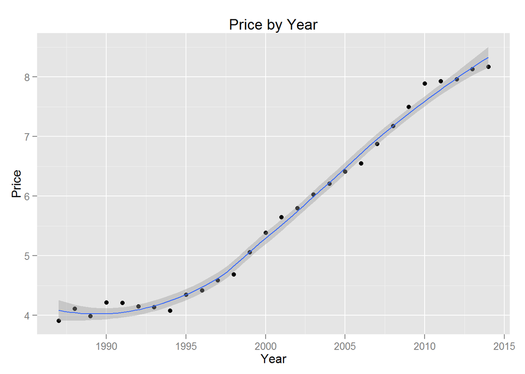

# Box Office Gross Profit

The following data on US and Canadian gross profit is from NATO Online. The inclusion of gross profit and exclusion of net profit is purely due to a lack of data for accurate net profit. The importance of the sudden rise and tapering in more recent years is very telling of the net profit, without knowing the actual net figure. The running costs of theatres has increased with the presence of newer projectors and expenses. This means the running cost has continued to rise, while the gross has began to taper.

| Year | Gross | Year | Gross |
| --- | --- | --- | --- |
| 1987 | 4.250 | 2001 | 8.110 |
| 1988 | 4.460 | 2002 | 9.090 |
| 1989 | 5.030 | 2003 | 9.150 |
| 1990 | 5.020 | 2004 | 9.290 |
| 1991 | 4.800 | 2005 | 8.820 |
| 1992 | 4.563 | 2006 | 9.170 |
| 1993 | 4.897 | 2007 | 9.632 |
| 1994 | 5.184 | 2008 | 9.634 |
| 1995 | 5.269 | 2009 | 10.600 |
| 1996 | 5.817 | 2010 | 10.580 |
| 1997 | 6.216 | 2011 | 10.180 |
| 1998 | 6.860 | 2012 | 10.790 |
| 1999 | 7.330 | 2013 | 10.920 |
| 2000 | 7.510 | 2014 | 10.400 |

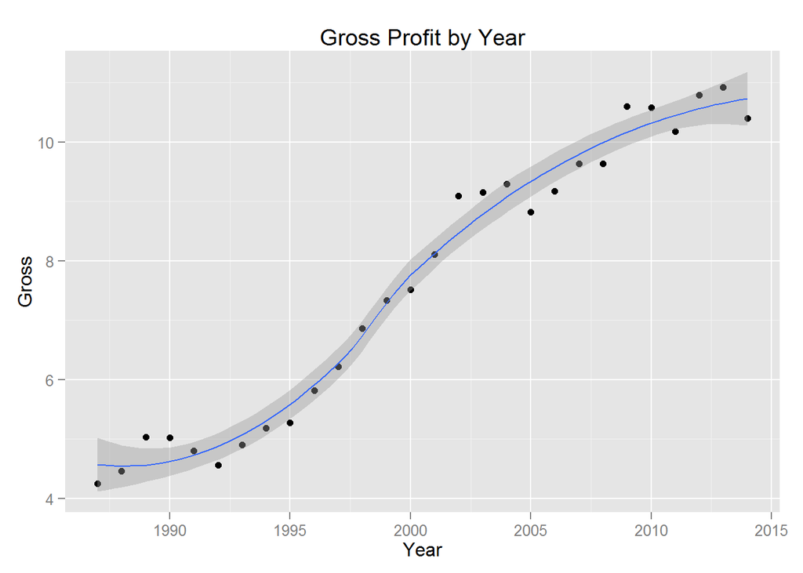

# Internet Traffic

The following table from Cisco shows a relative estimate of internet bandwidth used. The first row is per day, the second is per hour, and the rest are per second. The bandwidth used from 1992 to 1997 is relatively small. The amount begins to be substantial in 2002, and only increases from there. The estimated usage in 2019 is a staggering 51,694% increase over the usage in 2002.

| Year | Bandwidth |
| --- | --- |
| 1992 | 100 GBpd |
| 1997 | 100 GBph |
| 2002 | 100 GBps |
| 2007 | 2000 GBps |
| 2014 | 16144 GBps |
| 2019 | 51794 GBps |

The following is a table from Sandvine, outlining the overall bandwidth distribution from 2013. Netflix, Youtube, Amazon Video, and Hulu are all inside the top 10 for total bandwidth, with Netflix accounting for almost 32% of all data transferred. What this means is that people are watching a substantial amount of video every day, and aren’t going to the theatre to do it. BitTorrent and HTTP are important to the overall view as well. Not all file sharing and BitTorrent traffic are media files, but the majority are, and together they account for 14% of all traffic.

[figure not shown]

# Netflix

Taking a closer look at Netflix in particular, and grabbing their subscriber data directly from their revenue excel documents, we can see that their userbase has substantially increased each year following 2002.

| Year | Subscribers | % Change |
| --- | --- | --- |
| 2002 | 857000 | NA |
| 2003 | 1487000 | 73.51225 |
| 2004 | 2600000 | 74.84869 |
| 2005 | 4200000 | 61.53846 |
| 2006 | 6300000 | 50.00000 |
| 2007 | 7500000 | 19.04762 |
| 2008 | 9400000 | 25.33333 |
| 2009 | 12268000 | 30.51064 |
| 2010 | 20010000 | 63.10727 |
| 2011 | 26253000 | 31.19940 |
| 2012 | 33267000 | 26.71695 |
| 2013 | 44350000 | 33.31530 |
| 2014 | 57391000 | 29.40474 |

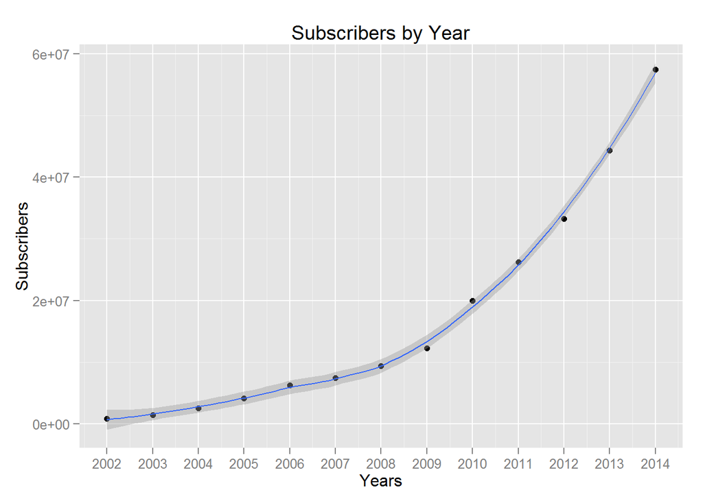

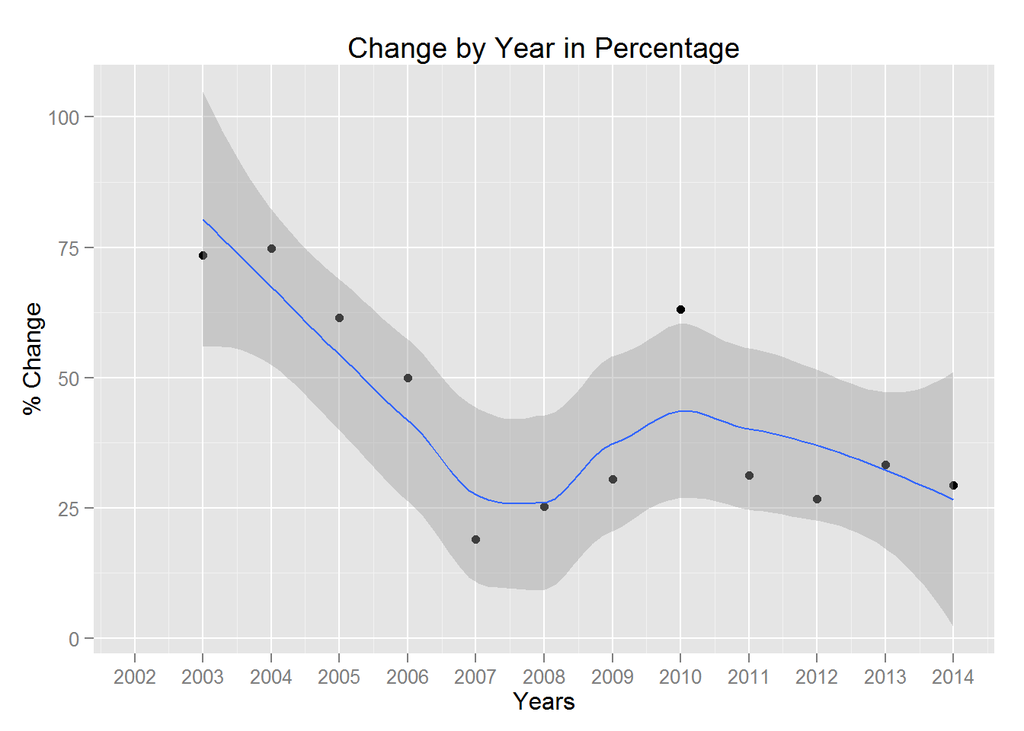

# Netflix and Theatre Attendance

Below is a plot, correlation, and summary stats on admissions numbers for theatres and netflix usage. The inital look is that as subscribers to netflix increase, the admissions to theatres go down.

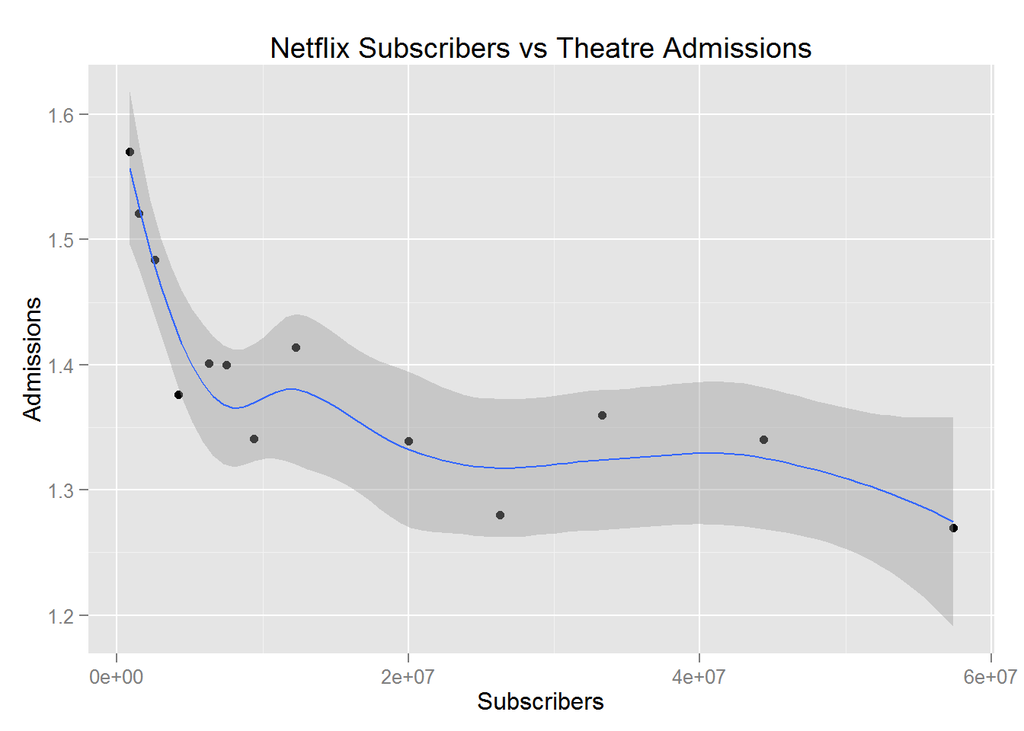

```
##
##  Pearson's product-moment correlation
##
## data:  netflix_tickets$Subscribers and netflix_tickets$Admissions
## t = -3.5237, df = 11, p-value = 0.004768
## alternative hypothesis: true correlation is not equal to 0
## 95 percent confidence interval:
##  -0.9128949 -0.2959170
## sample estimates:
##        cor
## -0.7281761
```

The correlation value above of -0.7281761 indicates that that the correlation is significant, while can also be gained from the p-value being below 0.05.

```
##
## Call:
## lm(formula = netflix_tickets$Subscribers ~ netflix_tickets$Admissions)
##
## Residuals:
##       Min        1Q    Median        3Q       Max
## -15543993  -8691426  -1851095   9829591  21956502
##
## Coefficients:
##                              Estimate Std. Error t value Pr(>|t|)
## (Intercept)                 223424510   58584966   3.814  0.00287 **
## netflix_tickets$Admissions -148023631   42008393  -3.524  0.00477 **
## ---
## Signif. codes:  0 '***' 0.001 '**' 0.01 '*' 0.05 '.' 0.1 ' ' 1
##
## Residual standard error: 12900000 on 11 degrees of freedom
## Multiple R-squared:  0.5302, Adjusted R-squared:  0.4875
## F-statistic: 12.42 on 1 and 11 DF,  p-value: 0.004768
```

The important note here is that the p value is much lower than the acceptable 0.05, and that the R-squared value is relatively high.

# Netflix, Theatre Price & Attendance

The question is whether the price of tickets has any indication on whether theatre attendance will be up that year, in addition, whether netflix usage has influence on both variables. The first look is at theatre attendance vs the price for a single movie. There is a slight trend for lower ticket prices to correlate with higher admission numbers. The actual correlation coefficient for Admissions and Price is -0.862661, which indicates a very strong negative relationship between the two, where admissions were significantly higher when ticket prices were lower. Adjusting for inflation may prove this relationship slightly less significant.

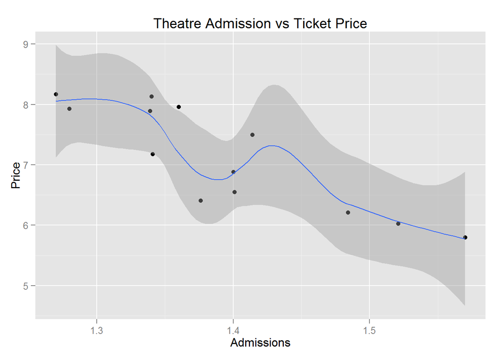

In the plot below, the count of Netflix subscribers vs price of the average ticket price is shown. This plot is saying that as subscribers for Netflix increase, the average price of tickets increases. This is mostly due to the price rising over time, and Netflix gaining popularity at the same time. It could be interpretted as the theatres needing to charge more in order to make up for lost quantity of tickets sold, or could be coincidence.

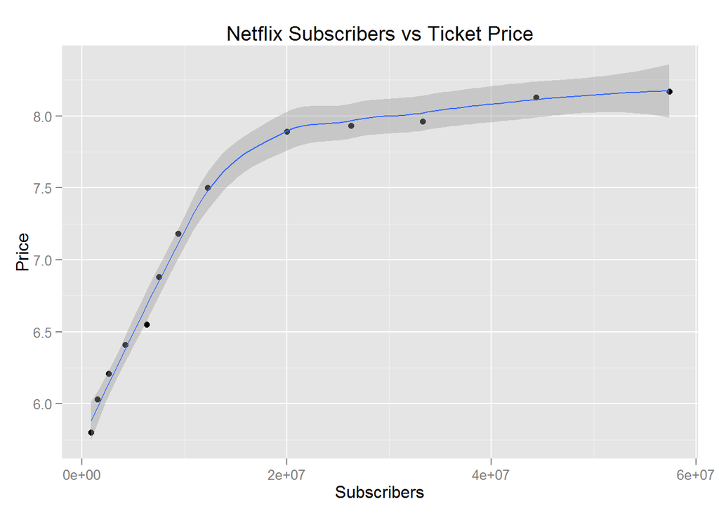

Below we can look at a model including price, attendance, and Netflix subscribers. According to the model, the price of a ticket is a much better indicator than the amount of netflix subscribers when trying to predict the total admissions to movies. How accurate the model is remains debateable.

```
##
## Call:
## lm(formula = net_tick_price$Admissions ~ net_tick_price$Subscribers +
##     net_tick_price$Price)
##
## Residuals:
##      Min       1Q   Median       3Q      Max
## -0.07961 -0.03897  0.01005  0.03481  0.05852
##
## Coefficients:
##                              Estimate Std. Error t value Pr(>|t|)
## (Intercept)                 2.056e+00  2.084e-01   9.868  1.8e-06 ***
## net_tick_price$Subscribers  2.767e-10  1.544e-09   0.179   0.8614
## net_tick_price$Price       -9.391e-02  3.236e-02  -2.902   0.0158 *
## ---
## Signif. codes:  0 '***' 0.001 '**' 0.01 '*' 0.05 '.' 0.1 ' ' 1
##
## Residual standard error: 0.04902 on 10 degrees of freedom
## Multiple R-squared:  0.745,  Adjusted R-squared:  0.694
## F-statistic: 14.61 on 2 and 10 DF,  p-value: 0.001078
```

# Conclusion

The dilemma with looking into a complex problem like declining theatre attendance is finding the correct niche to explore first. I believe that the base of the problem lies with the convenience factor of watching a movie from home, versus driving to a theatre, spending money on tickets and food, and sitting in a room with fifty other people. The indication that ticket price is a larger factor than a streaming service such as Netflix can also be extrapolated to include the high food prices found in theatres. People simply do not wish to pay extra for something that they do not find worth it.

If I were to continue with research, the next subject to look into is the attractiveness of going to a theatre for difference generations, versus who movies often target. From a shallow search, it seems that movies often target the teenage to early twenties crowd, yet the idea of going to a theatre is not appealing to the same group. Adults who enjoy going to the theatre, often cannot find a movie that targets them. It’s an interesting aspect of the overall problem and worth visiting.

My end consensus is that while ticket prices and streaming services do seem to be factors in declining sales, there are a myriad of other issues not represented in this project.

# Sources

- http://rpubs.com/catlin/rvest
- http://natoonline.org/data
- https://www.whitehutchinson.com/blog/2015/01/movie-attendance-continues-its-12-year-decline/
- http://www.cisco.com/c/en/us/solutions/collateral/service-provider/visual-networking-index-vni/VNI_Hyperconnectivity_WP.html
- https://www.sandvine.com/downloads/general/global-internet-phenomena/2013/2h-2013-global-internet-phenomena-report.pdf
- http://ir.netflix.com/results.cfm